# Logistic Regression in Breast Cancer Patients

Carmen Canedo

10 August 2020

# About

# Loading necessary libraries

These are the necessary libraries you will need to have loaded to follow along with the code below.

```r
library(cowplot)
```

# Loading in data

```r
# Reading in .csv
breast_cancer_original <- read.csv("Breast_cancer_data_Wisconsin_Stat302_2020.csv")
```

## Cleaning data

Renaming columns for clarity

```r
# Saving renamed columns into new data frame
breast_cancer <- breast_cancer_original %>%
  rename(clump_thickness = ClumpThick) %>%
  rename(size_uniformity = SizeUniforrm) %>%
  rename(shape_uniformity = shapeUniform) %>%
  rename(marginal_adhesion = Adhesion) %>%
  rename(cell_size = cell.cize) %>%
  rename(bare_nuclei = bareNuclei) %>%
  rename(bland_cromatin = Cromatin) %>%
  rename(normal_nucleoli = normalNuclei) %>%
  rename(mitoses = Mitozis) %>%
  rename(growth_class = Btype)
```

Normally, we would need to covert growth_class to a factor because its two values, 2 and 4, represent benign and malignant growths respectively. However, later in the code the `cor()` function requires that all columns are numeric. We will make those changes now.

```r
# Checking to make sure answer is correct
sapply(breast_cancer, class)
```

```
               ID   clump_thickness   size_uniformity  shape_uniformity marginal_adhesion         cell_size       bare_nuclei
        "numeric"         "numeric"         "numeric"         "numeric"         "numeric"         "numeric"         "numeric"
   bland_cromatin   normal_nucleoli           mitoses      growth_class
        "numeric"         "numeric"         "numeric"         "numeric"
```

# Analysis

Let’s take a look at the correlation matrix to get a general idea of the patterns in the data.

```r
bc_correlations
```

```
                           ID clump_thickness size_uniformity shape_uniformity marginal_adhesion   cell_size bare_nuclei
ID                 1.00000000     -0.05530844     -0.04160334      -0.04157607       -0.06487808 -0.04552828          NA
clump_thickness   -0.05530844      1.00000000      0.64491250       0.65458908        0.48635624  0.52181622          NA
size_uniformity   -0.04160334      0.64491250      1.00000000       0.90688191        0.70558181  0.75179913          NA
shape_uniformity  -0.04157607      0.65458908      0.90688191       1.00000000        0.68307920  0.71966844          NA
marginal_adhesion -0.06487808      0.48635624      0.70558181       0.68307920        1.00000000  0.59959907          NA
cell_size         -0.04552828      0.52181622      0.75179913       0.71966844        0.59959907  1.00000000          NA
bare_nuclei                NA              NA              NA               NA                NA          NA           1
bland_cromatin    -0.06005053      0.55842816      0.75572098       0.73594845        0.66671533  0.61610184          NA
normal_nucleoli   -0.05207195      0.53583455      0.72286482       0.71944632        0.60335241  0.62888069          NA
mitoses           -0.03490066      0.35003386      0.45869315       0.43891093        0.41763278  0.47910148          NA
growth_class      -0.08022565      0.71600136      0.81790374       0.81893374        0.69680021  0.68278453          NA
                  bland_cromatin normal_nucleoli     mitoses growth_class
ID                   -0.06005053     -0.05207195 -0.03490066  -0.08022565
clump_thickness       0.55842816      0.53583455  0.35003386   0.71600136
size_uniformity       0.75572098      0.72286482  0.45869315   0.81790374
shape_uniformity      0.73594845      0.71944632  0.43891093   0.81893374
marginal_adhesion     0.66671533      0.60335241  0.41763278   0.69680021
cell_size             0.61610184      0.62888069  0.47910148   0.68278453
bare_nuclei                   NA              NA          NA           NA
bland_cromatin        1.00000000      0.66587781  0.34416950   0.75661615
normal_nucleoli       0.66587781      1.00000000  0.42833575   0.71224362
mitoses               0.34416950      0.42833575  1.00000000   0.42317026
growth_class          0.75661615      0.71224362  0.42317026   1.00000000
```

We are going to use the backwards method to create our logistic model. We will first start with all variables included.

```r
summary(logistic)
```

```
Call:
glm(formula = growth_class ~ ., family = "binomial", data = breast_cancer)

Deviance Residuals:
     Min        1Q    Median        3Q       Max
-3.11976  -0.09259  -0.05121   0.02135   2.55168

Coefficients:
                    Estimate Std. Error z value Pr(>|z|)
(Intercept)       -1.192e+01  2.060e+00  -5.785 7.26e-09 ***
ID                 1.427e-07  5.465e-07   0.261 0.793936
clump_thickness    4.588e-01  1.583e-01   2.899 0.003745 **
size_uniformity   -9.845e-02  2.082e-01  -0.473 0.636288
shape_uniformity   5.116e-01  2.482e-01   2.062 0.039246 *
marginal_adhesion  2.266e-01  1.168e-01   1.941 0.052313 .
cell_size          1.283e-01  1.617e-01   0.794 0.427396
bare_nuclei1       1.712e+00  1.510e+00   1.134 0.256933
bare_nuclei10      5.381e+00  1.547e+00   3.479 0.000504 ***
bare_nuclei2       2.471e+00  1.612e+00   1.533 0.125326
bare_nuclei3       4.191e+00  1.596e+00   2.626 0.008650 **
bare_nuclei4       4.886e+00  1.705e+00   2.865 0.004167 **
bare_nuclei5       3.804e+00  1.633e+00   2.329 0.019849 *
bare_nuclei6       2.107e+01  2.630e+03   0.008 0.993606
bare_nuclei7       3.793e+00  1.917e+00   1.979 0.047837 *
bare_nuclei8       3.514e+00  1.648e+00   2.133 0.032959 *
bare_nuclei9       2.019e+01  1.767e+03   0.011 0.990883
bland_cromatin     5.489e-01  1.805e-01   3.042 0.002354 **
normal_nucleoli    1.442e-01  1.173e-01   1.230 0.218806
mitoses            4.214e-01  3.074e-01   1.371 0.170433
---
Signif. codes:  0 ‘***’ 0.001 ‘**’ 0.01 ‘*’ 0.05 ‘.’ 0.1 ‘ ’ 1

(Dispersion parameter for binomial family taken to be 1)

    Null deviance: 900.53  on 698  degrees of freedom
Residual deviance: 101.45  on 679  degrees of freedom
AIC: 141.45

Number of Fisher Scoring iterations: 17
```

## Interpretation

Using the information above, we can infer which variables have an effect on whether breast cancer patients in Wisconsin are likely to have benign versus malignant growths.

# Graphing

In order to graph the probabilities of the model below, we need to create a new data frame that has the probabilities.

## Creating graph

```
Ignoring unknown parameters: stoke
```

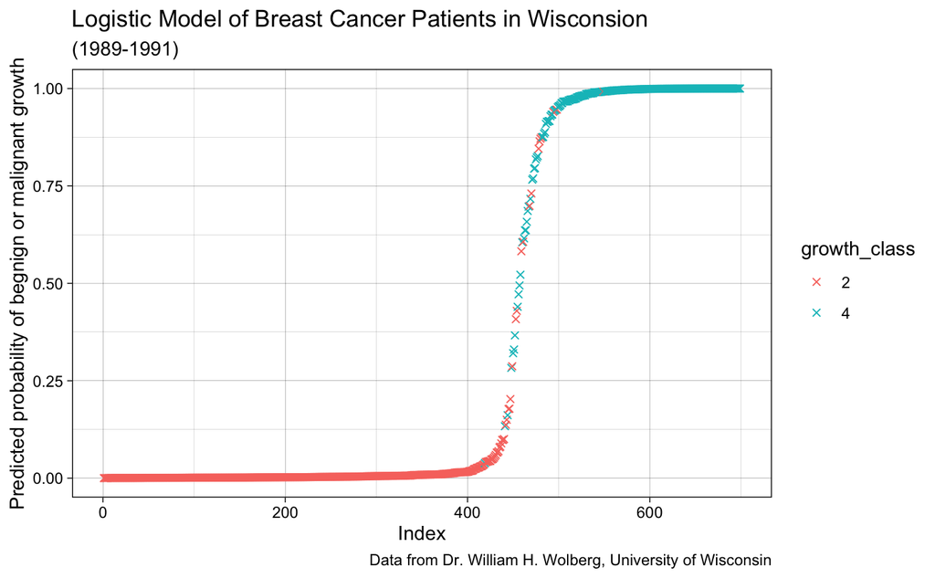

```r
ggplot(data = predicted_data, aes(x = rank, y = probability_of_growth_class)) +
  geom_point(aes(color = growth_class), alpha = 1, shape = 4, stoke = 2) +
  theme_set(theme_linedraw()) +
  labs(title = "Logistic Model of Breast Cancer Patients in Wisconsion",
       subtitle = "(1989-1991)",
       caption = "Data from Dr. William H. Wolberg, University of Wisconsin",
       x = "Index",
       y = "Predicted probability of begnign or malignant growth")
```